# Football Players

```python
import numpy as np
import pandas as pd
import matplotlib.pyplot as plt
import seaborn as sns
```

```python
df = pd.read_csv("Football Players Stats 2.csv")
df.columns
```

```
Index(['Player', 'Team', 'Nation', 'Pos', 'Age', 'MP', 'Starts', 'Min', '90s',
       'Gls', 'Ast', 'G-PK', 'PK', 'PKatt', 'CrdY', 'CrdR', 'Gls.1', 'Ast.1',
       'G+A', 'G-PK.1', 'G+A-PK', 'xG', 'npxG', 'xA', 'npxG+xA', 'xG.1',
       'xA.1', 'xG+xA', 'npxG.1', 'npxG+xA.1'],
      dtype='object')
```

A football player dataset typically contains detailed information about individual players' performance and statistics in football (soccer). The dataset usually includes a variety of attributes that capture different aspects of a player's involvement in matches, goals scored, assists, playing positions, disciplinary actions, and more. Such datasets are often used for analysis, statistical modeling, and gaining insights into player and team performance.

```python
df = pd.read_csv("Football Players Stats 2.csv")
df
```

|  | Player | Team | Nation | Pos | Age | MP | Starts | Min | 90s | Gls | ... | G+A-PK | xG | npxG | xA | npxG+xA | xG.1 | xA.1 | xG+xA | npxG.1 | npxG+xA.1 |
| --- | --- | --- | --- | --- | --- | --- | --- | --- | --- | --- | --- | --- | --- | --- | --- | --- | --- | --- | --- | --- | --- |
| 0 | Bukayo Saka | Arsenal | eng ENG | FW,MF | 19.0 | 38 | 36 | 2,978 | 33.1 | 11.0 | ... | 0.48 | 9.7 | 8.2 | 6.9 | 15.2 | 0.29 | 0.21 | 0.50 | 0.25 | 0.46 |
| 1 | Gabriel Dos Santos | Arsenal | br BRA | DF | 23.0 | 35 | 35 | 3,063 | 34.0 | 5.0 | ... | 0.15 | 2.7 | 2.7 | 0.8 | 3.5 | 0.08 | 0.02 | 0.10 | 0.08 | 0.10 |
| 2 | Aaron Ramsdale | Arsenal | eng ENG | GK | 23.0 | 34 | 34 | 3,060 | 34.0 | 0.0 | ... | 0.00 | 0.0 | 0.0 | 0.0 | 0.0 | 0.00 | 0.00 | 0.00 | 0.00 | 0.00 |
| 3 | Ben White | Arsenal | eng ENG | DF | 23.0 | 32 | 32 | 2,880 | 32.0 | 0.0 | ... | 0.00 | 1.0 | 1.0 | 0.6 | 1.6 | 0.03 | 0.02 | 0.05 | 0.03 | 0.05 |
| 4 | Martin Ødegaard | Arsenal | no NOR | MF | 22.0 | 36 | 32 | 2,785 | 30.9 | 7.0 | ... | 0.36 | 4.8 | 4.8 | 6.8 | 11.6 | 0.16 | 0.22 | 0.38 | 0.16 | 0.38 |
| ... | ... | ... | ... | ... | ... | ... | ... | ... | ... | ... | ... | ... | ... | ... | ... | ... | ... | ... | ... | ... | ... |
| 686 | Christian Marques | Wolverhampton Wanderers | ch SUI | DF | 18.0 | 0 | 0 | NaN | NaN | NaN | ... | NaN | NaN | NaN | NaN | NaN | NaN | NaN | NaN | NaN | NaN |
| 687 | Yerson Mosquera | Wolverhampton Wanderers | co COL | DF | 20.0 | 0 | 0 | NaN | NaN | NaN | ... | NaN | NaN | NaN | NaN | NaN | NaN | NaN | NaN | NaN | NaN |
| 688 | Louie Moulden | Wolverhampton Wanderers | eng ENG | GK | 19.0 | 0 | 0 | NaN | NaN | NaN | ... | NaN | NaN | NaN | NaN | NaN | NaN | NaN | NaN | NaN | NaN |
| 689 | Dion Sanderson | Wolverhampton Wanderers | eng ENG | DF | 21.0 | 0 | 0 | NaN | NaN | NaN | ... | NaN | NaN | NaN | NaN | NaN | NaN | NaN | NaN | NaN | NaN |
| 690 | James Storer | Wolverhampton Wanderers | NaN | GK | NaN | 0 | 0 | NaN | NaN | NaN | ... | NaN | NaN | NaN | NaN | NaN | NaN | NaN | NaN | NaN | NaN |

691 rows × 30 columns

The aim and objectives of the analysis based on player performance, team analysis, position analysis, expected goals analysis, minutes played, discipline, efficiency analysis, and age and performance can vary depending on the specific goals and context of the analysis. However, here are general objectives that such an analysis might aim to achieve:

1. **Player Performance:**
   - **Aim:** Evaluate the overall performance of individual players.
   - **Objectives:** Identify top goal scorers, players with high assists, and those with efficient goal-to-minute ratios.
2. **Team Analysis:**
   - **Aim:** Understand team dynamics and effectiveness.
   - **Objectives:** Determine teams with the highest total goals, most assists, average player age, defensive records, and disciplinary trends.
3. **Position Analysis:**
   - **Aim:** Explore the performance variations across different playing positions.
   - **Objectives:** Identify the positions with the highest average goals per player and analyze the distribution of age among players in different positions.
4. **Expected Goals Analysis:**
   - **Aim:** Assess how well players are performing compared to statistical expectations.
   - **Objectives:** Analyze the correlation between actual and expected goals, identify players exceeding their expected goals, and evaluate differences between actual and expected goals.
5. **Minutes Played:**
   - **Aim:** Examine player involvement and playing time.
   - **Objectives:** Identify players with the most minutes played, calculate average starts, and assess player contributions based on playing time.
6. **Discipline:**
   - **Aim:** Understand the disciplinary aspects of player behavior.
   - **Objectives:** Identify players with the most yellow and red cards, analyze team-wise average yellow cards, and explore the relationship between age and disciplinary actions.
7. **Efficiency Analysis:**
   - **Aim:** Evaluate the efficiency of players in converting chances.
   - **Objectives:** Calculate the goals-to-expected-goals ratio, identify players with the highest non-penalty goals per 90 minutes, and find players with the best combined non-penalty goals and assists per 90 minutes.
8. **Age and Performance:**
   - **Aim:** Explore the relationship between player age and performance metrics.
   - **Objectives:** Analyze the correlation between age and goals or assists, evaluate age distribution across different playing positions, and examine the relationship between age and disciplinary actions.

Overall, the analysis aims to provide insights into player and team performance, efficiency, and behavior, contributing to a better understanding of the factors influencing success in football. The specific objectives can be tailored based on the goals and interests of the analyst or researcher conducting the analysis.

# Player Performance

```python
# 1. Who are the top goal scorers in the dataset?
top_goal_scorers = df.nlargest(5, 'Gls')['Player']
top_goal_scorers
```

```
356        Mohamed Salah
556        Son Heung-min
423    Cristiano Ronaldo
553           Harry Kane
354           Sadio Mané
Name: Player, dtype: object
```

```
                Player   Gls
356      Mohamed Salah  23.0
556      Son Heung-min  23.0
423  Cristiano Ronaldo  18.0
553         Harry Kane  17.0
354         Sadio Mané  16.0
```

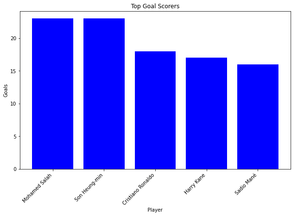

```python
import matplotlib.pyplot as plt

# 1. Who are the top goal scorers in the dataset?
top_goal_scorers = df.nlargest(5, 'Gls')[['Player', 'Gls']]

# Display the top goal scorers
print(top_goal_scorers)

# Plot the top goal scorers
plt.figure(figsize=(10, 6))
plt.bar(top_goal_scorers['Player'], top_goal_scorers['Gls'], color='blue')
plt.xlabel('Player')
plt.ylabel('Goals')
plt.title('Top Goal Scorers')
plt.xticks(rotation=45, ha='right')
plt.show()
```

```python
# Retrieve the player with the highest expected goals (xG)
highest_xG_player = df.loc[df['xG'].idxmax()]

# Get the number of goals scored by the player
goals_of_highest_xG_player = highest_xG_player['Gls']

print("Player with the highest expected goals (xG):", highest_xG_player['Player'])
print("Number of goals scored by the player:", goals_of_highest_xG_player)
```

```
Player with the highest expected goals (xG): Mohamed Salah
Number of goals scored by the player: 23.0
```

```python
# 3. Convert 'Min' column to numeric values
df['Min'] = pd.to_numeric(df['Min'], errors='coerce')

# Calculate 'GoalsPer90' using valid numeric values in 'Min'
df['GoalsPer90'] = df['Gls'] / (df['Min'] / 90)

# Find the player with the best goals-to-minutes ratio
best_goals_per_90_player = df.loc[df['GoalsPer90'].idxmax()]['Player']
best_goals_per_90_player
```

```
'Divock Origi'
```

```python
# 4. Identify the players with the most assists (Ast).
top_assist_players = df.nlargest(5, 'Ast')['Player']
top_assist_players
```

```
356             Mohamed Salah
353    Trent Alexander-Arnold
188               Mason Mount
323             Harvey Barnes
358          Andrew Robertson
Name: Player, dtype: object
```

```python
# 5. Who has the highest expected assists (xA) in the dataset?
highest_xA_player = df.loc[df['xA'].idxmax()]['Player']
highest_xA_player
```

```
'Trent Alexander-Arnold'
```

```python
# 6. Which players have the highest combined goals and assists (G+A)?
df['G_plus_A'] = df['G+A']
top_ga_players = df.nlargest(5, 'G_plus_A')['Player']
top_ga_players
```

```
377      Neco Williams
375       Divock Origi
209             Kenedy
373    Takumi Minamino
679          Chiquinho
Name: Player, dtype: object
```

```
              Player  G_plus_A
377    Neco Williams     11.25
375     Divock Origi      2.03
209           Kenedy      1.55
373  Takumi Minamino      1.45
679        Chiquinho      1.30
```

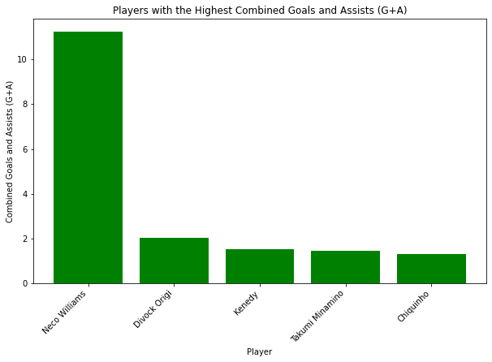

```python
import matplotlib.pyplot as plt

# 6. Which players have the highest combined goals and assists (G+A)?
df['G_plus_A'] = df['G+A']
top_ga_players = df.nlargest(5, 'G_plus_A')[['Player', 'G_plus_A']]

# Display the top players with the highest combined goals and assists
print(top_ga_players)

# Plot the top players with the highest combined goals and assists
plt.figure(figsize=(10, 6))
plt.bar(top_ga_players['Player'], top_ga_players['G_plus_A'], color='green')
plt.xlabel('Player')
plt.ylabel('Combined Goals and Assists (G+A)')
plt.title('Players with the Highest Combined Goals and Assists (G+A)')
plt.xticks(rotation=45, ha='right')
plt.show()
```

# Team Analysis

```python
# 7. Which team has the highest total goals in the dataset?
team_highest_goals = df.groupby('Team')['Gls'].sum().idxmax()
team_highest_goals
```

```
'Manchester City'
```

```python
# 8. Identify the team with the most assists (Ast) in the dataset.
team_most_assists = df.groupby('Team')['Ast'].sum().idxmax()
team_most_assists
```

```
'Liverpool'
```

```python
# 9. Calculate the average age of players for each team.
average_age_per_team = df.groupby('Team')['Age'].mean()
average_age_per_team
```

```
Team
Arsenal                    22.487805
Aston Villa                23.658537
Brentford                  23.527778
Brighton & Hove Albion     23.685714
Burnley                    27.032258
Chelsea                    25.387097
Crystal Palace             25.400000
Everton                    24.550000
Leeds United               22.750000
Leicester City             25.375000
Liverpool                  24.428571
Manchester City            24.121212
Manchester United          25.055556
Newcastle United           26.515152
Norwich City               23.588235
Southampton                24.931034
Tottenham Hotspur          23.542857
Watford                    25.384615
West Ham United            25.516129
Wolverhampton Wanderers    23.939394
Name: Age, dtype: float64
```

```python
# 10. Determine which team has the most yellow cards (CrdY) in total.
team_most_yellow_cards = df.groupby('Team')['CrdY'].sum().idxmax()
team_most_yellow_cards
```

```
'Leeds United'
```

```python
# 11. Which team has the best defensive record based on goals conceded?
team_best_defense = df.groupby('Team')['Gls.1'].sum().idxmin()
team_best_defense
```

```
'Norwich City'
```

# Position Analysis

```python
# 12. Which playing position (Pos) has the highest average goals per player?
average_goals_per_position = df.groupby('Pos')['Gls'].mean().idxmax()
average_goals_per_position
```

```
'FW'
```

```python
# 13. Identify the most common nationality (Nation) among defenders (DF).
most_common_nationality_defenders = df[df['Pos'] == 'DF']['Nation'].mode().iloc[0]
most_common_nationality_defenders
```

```
'eng\xa0ENG'
```

```python
# 14. Calculate the average age of midfielders (MF) and forwards (FW).
average_age_midfielders = df[df['Pos'] == 'MF']['Age'].mean()
average_age_forwards = df[df['Pos'] == 'FW']['Age'].mean()
average_age_midfielders
```

```
23.955128205128204
```

```python
average_age_forwards
```

```
24.31313131313131
```

```python
# 15. Who are the top-scoring goalkeepers (GK) in terms of goals scored?
top_scoring_goalkeepers = df[df['Pos'] == 'GK'].nlargest(3, 'Gls')['Player']
top_scoring_goalkeepers
```

```
2        Aaron Ramsdale
20           Bernd Leno
42    Emiliano Martínez
Name: Player, dtype: object
```

```python
import matplotlib.pyplot as plt

# 15. Who are the top-scoring goalkeepers (GK) in terms of goals scored?
goalkeepers = df[df['Pos'] == 'GK']
top_goalkeeping_scorers = goalkeepers.nlargest(5, 'Gls')['Player', 'Gls']

# Display the top-scoring goalkeepers
print(top_goalkeeping_scorers)

# Plot the top-scoring goalkeepers in a pie chart
plt.figure(figsize=(8, 8))
plt.pie(top_goalkeeping_scorers['Gls'], labels=top_goalkeeping_scorers['Player'], autopct='%1.1f%%', startangle=140)
plt.title('Top-Scoring Goalkeepers in Terms of Goals Scored')
plt.show()
```

[output not shown]

# Expected Goals Analysis

```python
# 16. Is there a correlation between actual goals (Gls) and expected goals (xG)?
correlation_goals_xG = df['Gls'].corr(df['xG'])
correlation_goals_xG
```

```
0.9345941413427254
```

```python
# 17. Which player has the highest non-penalty expected goals (npxG)?
highest_npxG_player = df.loc[df['npxG'].idxmax()]['Player']
highest_npxG_player
```

```
'Harry Kane'
```

```python
# 18. Calculate the difference between actual goals and expected goals for each player.
df['Goals_minus_xG'] = df['Gls'] - df['xG']
df['Goals_minus_xG']
```

```
0      1.3
1      2.3
2      0.0
3     -1.0
4      2.2
      ...
686    NaN
687    NaN
688    NaN
689    NaN
690    NaN
Name: Goals_minus_xG, Length: 691, dtype: float64
```

# Minutes Played

```python
# 19. Identify the players with the most minutes played (Min).
most_minutes_played_players = df.nlargest(5, 'Min')['Player']
most_minutes_played_players
```

```
338       James Justin
135        Enock Mwepu
334    Ricardo Pereira
363    Ibrahima Konaté
365    Roberto Firmino
Name: Player, dtype: object
```

```python
# 20. Calculate the average number of starts for players.
average_starts_per_player = df['Starts'].mean()
average_starts_per_player
```

```
12.098408104196816
```

# Discipline

```
                 Player  CrdR
47           Ezri Konsa   2.0
663        Raúl Jiménez   2.0
1    Gabriel Dos Santos   1.0
5          Granit Xhaka   1.0
9            Martinelli   1.0
```

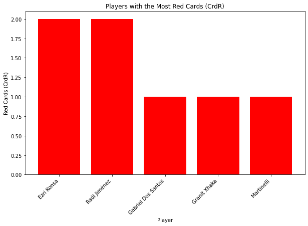

```python
import matplotlib.pyplot as plt

# 21. Who are the players with the most red cards (CrdR)?
top_red_card_players = df.nlargest(5, 'CrdR')[['Player', 'CrdR']]

# Display the top players with the most red cards
print(top_red_card_players)

# Plot the top players with the most red cards
plt.figure(figsize=(10, 6))
plt.bar(top_red_card_players['Player'], top_red_card_players['CrdR'], color='red')
plt.xlabel('Player')
plt.ylabel('Red Cards (CrdR)')
plt.title('Players with the Most Red Cards (CrdR)')
plt.xticks(rotation=45, ha='right')
plt.show()
```

```python
# 22. Calculate the average number of yellow cards (CrdY) per team.
average_yellow_cards_per_team = df.groupby('Team')['CrdY'].mean()
average_yellow_cards_per_team
```

```
Team
Arsenal                    2.481481
Aston Villa                2.612903
Brentford                  2.241379
Brighton & Hove Albion     2.769231
Burnley                    2.956522
Chelsea                    2.423077
Crystal Palace             2.875000
Everton                    2.484848
Leeds United               3.366667
Leicester City             1.964286
Liverpool                  1.851852
Manchester City            1.615385
Manchester United          2.655172
Newcastle United           2.793103
Norwich City               2.035714
Southampton                2.600000
Tottenham Hotspur          2.760000
Watford                    2.100000
West Ham United            2.080000
Wolverhampton Wanderers    2.384615
Name: CrdY, dtype: float64
```

```python
 #23. Analyze the relationship between yellow cards and player age.
correlation_yellow_cards_age = df['CrdY'].corr(df['Age'])
correlation_yellow_cards_age
```

```
0.14387360605551852
```

# Efficiency Analysis

```python
# 24. Calculate the ratio of goals to expected goals (G/xG) for each player.
df['Goals_to_xG_ratio'] = df['Gls'] / df['xG']
df['Goals_to_xG_ratio']
```

```
0      1.134021
1      1.851852
2           NaN
3      0.000000
4      1.458333
         ...
686         NaN
687         NaN
688         NaN
689         NaN
690         NaN
Name: Goals_to_xG_ratio, Length: 691, dtype: float64
```

```python
# 25. Determine which players have the highest non-penalty goals per 90 minutes.
df['NonPenaltyGoalsPer90'] = df['G-PK.1'] / (df['Min'] / 90)
top_non_penalty_goals_per_90 = df.nlargest(5, 'NonPenaltyGoalsPer90')['Player']
top_non_penalty_goals_per_90
```

```
482        Jeff Hendrick
445    Donny van de Beek
375         Divock Origi
373      Takumi Minamino
614          Dan Gosling
Name: Player, dtype: object
```

```python
# 26. Who has the best combined non-penalty goals and assists per 90 minutes (G+A-PK)?
df['NonPenalty_G_plus_A_per90'] = (df['G+A-PK']) / (df['Min'] / 90)
best_non_penalty_ga_per_90 = df.loc[df['NonPenalty_G_plus_A_per90'].idxmax()]['Player']
best_non_penalty_ga_per_90
```

```
'Neco Williams'
```

# Age and Performance

```python
# 27. Is there a correlation between player age and performance metrics like goals or assists?
correlation_age_performance = df['Age'].corr(df['Gls'])
correlation_age_performance
```

```
0.08253934168678692
```

```python
# 28. How does the age distribution differ for different playing positions?
age_distribution_by_position = df.groupby('Pos')['Age'].mean()
age_distribution_by_position
```

```
Pos
DF       24.409483
DF,FW    27.500000
DF,MF    24.777778
FW       24.313131
FW,DF    28.500000
FW,MF    22.677419
GK       27.328767
MF       23.955128
MF,DF    27.545455
MF,FW    23.692308
Name: Age, dtype: float64
```

```python
# 29. Analyze the relationship between age and disciplinary actions (yellow and red cards).
correlation_age_discipline = df['Age'].corr(df['CrdY'] + df['CrdR'])
correlation_age_discipline
```

```
0.14323800376635235
```

```python
# 30. Calculate the average age for players from different nationalities (Nation).
average_age_by_nationality = df.groupby('Nation')['Age'].mean().reset_index()
average_age_by_nationality
```

|  | Nation | Age |
| --- | --- | --- |
| 0 | al ALB | 19.000000 |
| 1 | ao ANG | 27.000000 |
| 2 | ar ARG | 27.625000 |
| 3 | at AUT | 27.000000 |
| 4 | ba BIH | 31.000000 |
| ... | ... | ... |
| 61 | ve VEN | 31.000000 |
| 62 | wls WAL | 22.882353 |
| 63 | xk KVX | 25.000000 |
| 64 | zm ZAM | 22.500000 |
| 65 | zw ZIM | 27.000000 |

66 rows × 2 columns